# Load Libraries

```python
import os
import cv2
import time
import numpy as np
import pandas as pd
from matplotlib import pyplot as plt
%matplotlib inline
import sklearn
from google.colab.patches import cv2_imshow
from tensorflow.keras.models import Sequential
from tensorflow.keras.layers import Dense,Dropout,Flatten,BatchNormalization
from tensorflow.keras.layers import Conv2D,MaxPooling2D
```

```python
import tensorflow as tf
! pip install tflearn
```

# Load Data

```python
import tflearn.datasets.oxflower17 as oxflower17
```

```
WARNING:tensorflow:From /usr/local/lib/python3.7/dist-packages/tensorflow/python/compat/v2_compat.py:96: disable_resource_variables (from tensorflow.python.ops.variable_scope) is deprecated and will be removed in a future version.
Instructions for updating:
non-resource variables are not supported in the long term
```

```python
X, Y = oxflower17.load_data(one_hot=True)
```

```python
# checking the shape of Data
X.shape # 3 channel 1360 images in train
```

```
(1360, 224, 224, 3)
```

```python
Y.shape
```

```
(1360, 17)
```

```python
# preparing labels
y = pd.DataFrame(Y)
labels = []
cols =y.columns
for i in range(y.shape[0]):
    for j in cols:
      if y.iloc[i,j] == 1.0:
        labels.append(j)
print("length of labels",len(labels))
```

```
length of labels 1360
```

```python
# checking the above operation
print("label of 1st image",labels[0])
print("label of 1st image",Y[0])
print("label of 2nd image",labels[1])
print("label of 2nd image",Y[1])
```

```
label of 1st image 13
label of 1st image [0. 0. 0. 0. 0. 0. 0. 0. 0. 0. 0. 0. 0. 1. 0. 0. 0.]
label of 2nd image 7
label of 2nd image [0. 0. 0. 0. 0. 0. 0. 1. 0. 0. 0. 0. 0. 0. 0. 0. 0.]
```

```python
# displaying labels,
pd.Series(labels).value_counts()
# there is no class imbalance
```

```
16    80
7     80
1     80
2     80
3     80
4     80
5     80
6     80
8     80
15    80
9     80
10    80
11    80
12    80
13    80
14    80
0     80
dtype: int64
```

# Data Visualization

[figure not shown]

```python
# displaying few of the images
plt.figure(figsize=(12,15))
for i in range(25):
  plt.subplot(5,5,i+1)
  plt.imshow(X[i])
  plt.title("Shape {}".format(X[i].shape))
  plt.title("Image label {}".format(labels[i]))
  plt.xticks([])
  plt.yticks([])
```

## Filters

### Gaussian Blur || Smoothing

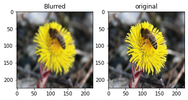

```python
#Filters
import cv2
#  Gaussian Blur Filter
img = X[0]
img_blur = cv2.GaussianBlur(img,(5,5),5)
plt.subplot(121)
plt.imshow(img_blur)
plt.title("Blurred")
plt.subplot(122)
plt.imshow(img)
plt.title("original")
```

[figure not shown]

```python
#  Gaussian Blur Filter
img = X[100]
img_blur = cv2.GaussianBlur(img,(5,5),5)
plt.subplot(121)
plt.imshow(img_blur)
plt.title("Blurred")
plt.subplot(122)
plt.imshow(img)
plt.title("original")
```

### Contours by Binary Thresholding

```
([], <a list of 0 Text major ticklabel objects>)
```

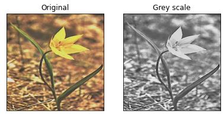

```python
# contours for shape analysis and object detection
# 2 methods to find contours in the image
# 1.0 canny edge detection
# 2.0 Binary Thresholding
img = X[450]
img_grey = cv2.cvtColor(img,cv2.COLOR_BGR2GRAY)
plt.figure(figsize=(10,10))
plt.subplot(131)
plt.imshow(img)
plt.title("Original")
plt.xticks([])
plt.yticks([])
plt.subplot(132)
plt.imshow(img_grey, cmap="Greys_r")
plt.title("Grey scale")
plt.xticks([])
plt.yticks([])
```

[figure not shown]

```python
# tresholding
img_grey.dtype= np.uint8
ret, thresh = cv2.threshold(img_grey,100,225,0)
cv2_imshow(cv2.resize(thresh,(250,250)))
```

```python
# finding the contours
contours, hierarchy = cv2.findContours(thresh,cv2.RETR_EXTERNAL,cv2.CHAIN_APPROX_SIMPLE) # arguments> image, mode and method , sequence wise
```

[figure not shown]

```python
img = cv2.drawContours(img, contours, -1, (0,50,0),0)
cv2_imshow(img)
```

```
Clipping input data to the valid range for imshow with RGB data ([0..1] for floats or [0..255] for integers).
```

[figure not shown]

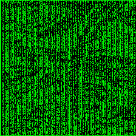

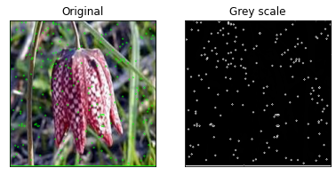

```python
# Trying on some other image using thresholding
img = X[500]
img_grey = cv2.cvtColor(img,cv2.COLOR_BGR2GRAY)
plt.figure(figsize=(10,10))
plt.subplot(131)
plt.imshow(img)
plt.title("Original")
plt.xticks([])
plt.yticks([])
plt.subplot(132)
plt.imshow(img_grey, cmap="Greys_r")
plt.title("Grey scale")
plt.xticks([])
plt.yticks([])
# tresholding
img_grey.dtype= np.uint8
ret, thresh = cv2.threshold(img_grey,127,225,0)
cv2_imshow(cv2.resize(thresh,(200,200)))
# finding the contours
contours, hierarchy = cv2.findContours(thresh,cv2.RETR_TREE,cv2.CHAIN_APPROX_SIMPLE)
img = cv2.drawContours(img, contours, -1, (0,255,0),0)
cv2_imshow(img)
```

### Contours by Finding Canny edges

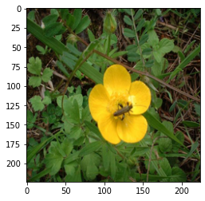

```python
plt.imshow(X[851])
```

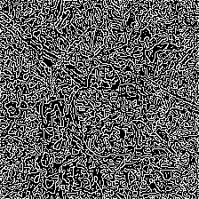

```
Number of Contours found = 1324
```

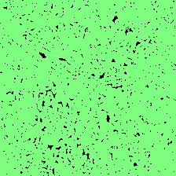

```python
img = X[851]
#img_grey = cv2.cvtColor(img,cv2.COLOR_BGR2GRAY)
#img_grey.dtype = np.uint8
img.dtype = np.uint8
edged = cv2.Canny(img,100,200,apertureSize = 5, L2gradient = True)
cv2_imshow(edged)
# Finding Contours
contours, hierarchy = cv2.findContours(edged,cv2.RETR_TREE, cv2.CHAIN_APPROX_SIMPLE)
print("Number of Contours found = " + str(len(contours)))
# Draw all contours
# -1 signifies drawing all contours
img.dtype = np.float32
cv2.drawContours(img, contours, -1, (127, 255, 127), 2)
cv2_imshow(img)
```

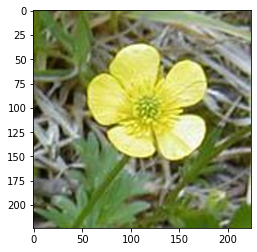

```python
plt.imshow(X[656])
```

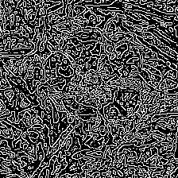

```
Number of Contours found = 1280
```

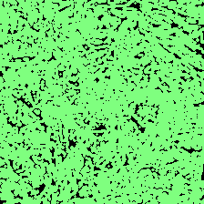

```python
img = X[656]
#img_grey = cv2.cvtColor(img,cv2.COLOR_BGR2GRAY)
#img_grey.dtype = np.uint8
img.dtype = np.uint8
edged = cv2.Canny(img,100,200,apertureSize = 5, L2gradient = True)
cv2_imshow(edged)
# Finding Contours
contours, hierarchy = cv2.findContours(edged,cv2.RETR_TREE, cv2.CHAIN_APPROX_SIMPLE)
print("Number of Contours found = " + str(len(contours)))
# Draw all contours
# -1 signifies drawing all contours
img.dtype = np.float32
cv2.drawContours(img, contours, -1, (127, 255, 127), 2)
cv2_imshow(img)
```

### Embossing Filter

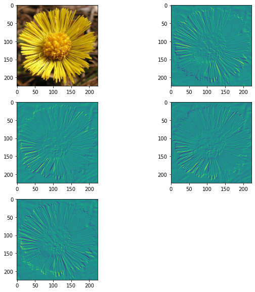

```python
img  = X[3]
kernel_emboss_1 = np.array([[0,-1,-1], #botton left
                            [1,0,-1],
                            [1,1,0]])
kernel_emboss_2 = np.array([[-1,-1,0],
                            [-1,0,1],
                             [0,1,1]]) #botting right
kernel_emboss_3 = np.array([[1,1,0],
                            [1,0,-1],
                            [0,-1,-1]]) # top left

kernel_emboss_4 = np.array([[0,1,1],  # top right
                            [-1,0,1],
                            [-1,-1,0]])

# converting the image to grayscale
img_grey = cv2.cvtColor(img,cv2.COLOR_BGR2GRAY)

# applying the kernels to the grayscale image and adding the offset
output_1 = cv2.add(cv2.filter2D(img_grey, -1, kernel_emboss_1), 128)
output_2 = cv2.add(cv2.filter2D(img_grey, -1, kernel_emboss_2) , 128)
output_3 = cv2.add(cv2.filter2D(img_grey, -1, kernel_emboss_3) , 128)
output_4 = cv2.add(cv2.filter2D(img_grey, -1, kernel_emboss_4) , 128)

plt.figure(figsize=(10,10))
plt.subplot(321)
plt.imshow( img)
plt.subplot(322)
plt.imshow( output_1)
plt.subplot(323)
plt.imshow( output_2)
plt.subplot(324)
plt.imshow( output_3)
plt.subplot(325)
plt.imshow( output_4)
```

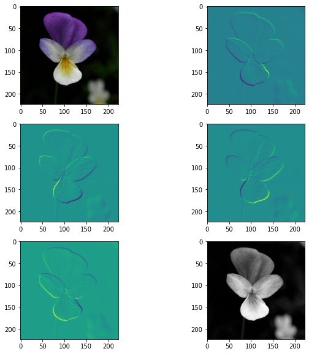

```python
img  = X[1300]
kernel_emboss_1 = np.array([[0,-1,-1], #botton left
                            [1,0,-1],
                            [1,1,0]])
kernel_emboss_2 = np.array([[-1,-1,0],
                            [-1,0,1],
                             [0,1,1]]) #botting right
kernel_emboss_3 = np.array([[1,1,0],
                            [1,0,-1],
                            [0,-1,-1]]) # top left

kernel_emboss_4 = np.array([[0,1,1],  # top right
                            [-1,0,1],
                            [-1,-1,0]])

# converting the image to grayscale
img_grey = cv2.cvtColor(img,cv2.COLOR_BGR2GRAY)

# applying the kernels to the grayscale image and adding the offset
output_1 = cv2.add(cv2.filter2D(img_grey, -1, kernel_emboss_1), 128)
output_2 = cv2.add(cv2.filter2D(img_grey, -1, kernel_emboss_2) , 128)
output_3 = cv2.add(cv2.filter2D(img_grey, -1, kernel_emboss_3) , 128)
output_4 = cv2.add(cv2.filter2D(img_grey, -1, kernel_emboss_4) , 128)

plt.figure(figsize=(10,10))
plt.subplot(321)
plt.imshow( img)
plt.subplot(322)
plt.imshow( output_1)
plt.subplot(323)
plt.imshow( output_2)
plt.subplot(324)
plt.imshow( output_3)
plt.subplot(325)
plt.imshow( output_4)
plt.subplot(326)
plt.imshow(img_grey,cmap="Greys_r")
```

# Modelling

## Data Preparation

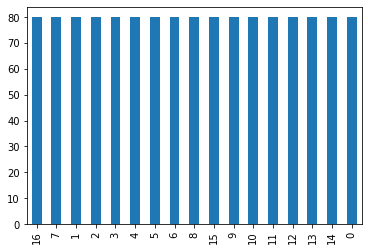

```python
# checking class imbalance
pd.Series(labels).value_counts().plot(kind="bar")
# no class imbalance in the data
```

```python
# Normalizing the data
#X = X/255
```

```python
# checking the above operation
print(X[100].min())
print(X[100].max())
print(X[11].min())
print(X[11].max())
```

```
0.0
0.99607843
0.0
1.0
```

```python
# Splitting the data
seed = 0
from sklearn.model_selection import train_test_split
x_train, x_test,y_train,y_test = train_test_split(X,Y,test_size=0.20,random_state=seed,stratify=Y)
```

```python
print("Shape of X Train {}".format(x_train.shape))
print("Shape of X Test {}".format(x_test.shape))
print("Shape of Y Train {}".format(y_train.shape))
print("Shape of Y Test {}".format(y_test.shape))
```

```
Shape of X Train (1088, 224, 224, 3)
Shape of X Test (272, 224, 224, 3)
Shape of Y Train (1088, 17)
Shape of Y Test (272, 17)
```

```python
print("Type of X Train {}".format(type(x_train)))
print("Type of X Test {}".format(type(x_test)))
print("Type of Y Train {}".format(type(y_train)))
print("Type of Y Test {}".format(type(y_test)))
```

```
Type of X Train <class 'numpy.ndarray'>
Type of X Test <class 'numpy.ndarray'>
Type of Y Train <class 'numpy.ndarray'>
Type of Y Test <class 'numpy.ndarray'>
```

```python
# Data Augmentation using keras
from keras.preprocessing.image import ImageDataGenerator
datagen = ImageDataGenerator(
        rotation_range=180,  # randomly rotate images in the range
        zoom_range = 0.1, # Randomly zoom image
        width_shift_range=0.2,  # randomly shift images horizontally
        height_shift_range=0.2,  # randomly shift images vertically
        horizontal_flip=True,  # randomly flip images horizontally
        vertical_flip=True
         # randomly flip images vertically
    )
datagen.fit(x_train)
```

## Supervised Learning Algorithms

SVM, DT, KNN with Vanilla CNN + Max Pooling

```python
model = Sequential()
model.add(Conv2D(32,(3,3),input_shape = x_train.shape[1:],activation="relu"))
model.add(MaxPooling2D(pool_size=(2,2)))
model.add(Dropout(0.4))
model.add(Conv2D(64,(3,3),activation="relu"))
model.add(MaxPooling2D(pool_size=(2,2)))
model.add(Dropout(0.6))
model.add(Conv2D(128,(3,3),activation="relu"))
model.add(MaxPooling2D(pool_size=(2,2)))
model.add(Dropout(0.8))
model.add(Conv2D(128,(3,3),activation="relu"))
model.add(MaxPooling2D(pool_size=(2,2)))
model.add(Flatten())
model.add(Dense(4096,activation="relu"))
model.add(Dense(17,activation="softmax"))
model.compile(loss="categorical_crossentropy",optimizer="adam",metrics=['accuracy'])
```

```python
model_1 = model
model_1.summary()
```

```
Model: "sequential_1"
_________________________________________________________________
Layer (type)                 Output Shape              Param #
=================================================================
conv2d (Conv2D)              (None, 222, 222, 32)      896
_________________________________________________________________
max_pooling2d (MaxPooling2D) (None, 111, 111, 32)      0
_________________________________________________________________
dropout (Dropout)            (None, 111, 111, 32)      0
_________________________________________________________________
conv2d_1 (Conv2D)            (None, 109, 109, 64)      18496
_________________________________________________________________
max_pooling2d_1 (MaxPooling2 (None, 54, 54, 64)        0
_________________________________________________________________
dropout_1 (Dropout)          (None, 54, 54, 64)        0
_________________________________________________________________
conv2d_2 (Conv2D)            (None, 52, 52, 128)       73856
_________________________________________________________________
max_pooling2d_2 (MaxPooling2 (None, 26, 26, 128)       0
_________________________________________________________________
dropout_2 (Dropout)          (None, 26, 26, 128)       0
_________________________________________________________________
conv2d_3 (Conv2D)            (None, 24, 24, 128)       147584
_________________________________________________________________
max_pooling2d_3 (MaxPooling2 (None, 12, 12, 128)       0
_________________________________________________________________
flatten (Flatten)            (None, 18432)             0
_________________________________________________________________
dense (Dense)                (None, 4096)              75501568
_________________________________________________________________
dense_1 (Dense)              (None, 17)                69649
=================================================================
Total params: 75,812,049
Trainable params: 75,812,049
Non-trainable params: 0
_________________________________________________________________
```

```python
# extracting features of from above CNN to train an SVM
import tensorflow as tf
model_feat = tf.keras.Model(inputs=model_1.input,outputs=model.get_layer("dense_15").output)
feat_train = model_feat.predict(x_train)
feat_test = model_feat.predict(x_test)
```

```python
# checking the score support vector machines
from sklearn.svm import SVC
svm = SVC(kernel="rbf")
svm.fit(feat_train,np.argmax(y_train,axis=1))
svm.score(feat_test,np.argmax(y_test,axis=1))
```

```
0.27205882352941174
```

```python
# checking on Decision Tree classifier
from sklearn.tree import DecisionTreeClassifier
dt = DecisionTreeClassifier(criterion = "entropy", random_state = 100,max_depth=3, min_samples_leaf=5)
dt.fit(feat_train,np.argmax(y_train,axis=1))
dt.score(feat_test,np.argmax(y_test,axis=1))
```

```
0.13970588235294118
```

```python
# checking on KNN
from sklearn.neighbors import KNeighborsClassifier
knn = KNeighborsClassifier(n_neighbors=12)
knn.fit(feat_train,np.argmax(y_train,axis=-1))
knn.score(feat_test,np.argmax(y_test,axis=1))
```

```
0.22058823529411764
```

None of the supervised machine learning alogrithm gave a good score so far

## Nueral Networks MLP

```python
model_1.fit(x =x_train,y=y_train,batch_size=32,epochs=100,validation_data=(x_test,y_test))
```

```
Train on 1088 samples, validate on 272 samples
```

```
<tensorflow.python.keras.callbacks.History at 0x7f629f93efd0>
```

```python
model_1.evaluate(x_test,y_test)
```

```
[2.8332144653095916, 0.05882353]
```

```python
# Multi Layer Perceptron
model_2 = Sequential()
model_2.add(Flatten(input_shape=(224,224,3)))
model_2.add(Dense(512,activation="relu",kernel_initializer='normal'))
model_2.add(BatchNormalization())
model_2.add(Dropout(0.2))
model_2.add(Dense(64,activation="relu",kernel_initializer='normal'))
model_2.add(BatchNormalization())
model_2.add(Dense(32,activation="relu",kernel_initializer='normal'))
model_2.add(BatchNormalization())
model_2.add(Dense(16,activation="relu",kernel_initializer='normal'))
model_2.add(BatchNormalization())
model_2.add(Dense(17))
model_2.compile(optimizer="adam",loss="categorical_crossentropy",metrics=['accuracy'])
```

```python
model_2.fit(x_train,y_train,epochs=30,batch_size=100,validation_data=(x_test,y_test))
```

```
Train on 1088 samples, validate on 272 samples
```

```
<tensorflow.python.keras.callbacks.History at 0x7f528b971150>
```

```python
model_2.evaluate(x_test,y_test)
```

```
[6.809272485620835, 0.029411765]
```

## CNN

```python
model = Sequential()
model.add(Conv2D(32,(3,3),input_shape = x_train.shape[1:],activation="relu"))
model.add(MaxPooling2D(pool_size=(2,2)))
#model.add(Dropout(0.4))
model.add(Conv2D(64,(3,3),activation="relu"))
model.add(MaxPooling2D(pool_size=(2,2)))
#model.add(Dropout(0.6))
model.add(Conv2D(128,(3,3),activation="relu"))
model.add(MaxPooling2D(pool_size=(2,2)))
#model.add(Dropout(0.8))
model.add(Conv2D(256,(3,3),activation="relu"))
model.add(MaxPooling2D(pool_size=(2,2)))
model.add(Conv2D(256,(3,3),activation="relu"))
model.add(MaxPooling2D(pool_size=(2,2)))
model.add(Flatten())
model.add(Dense(1024,activation="relu"))
model.add(Dense(17,activation="softmax"))
model.summary()
```

```
Model: "sequential_1"
_________________________________________________________________
Layer (type)                 Output Shape              Param #
=================================================================
conv2d_5 (Conv2D)            (None, 222, 222, 32)      896
_________________________________________________________________
max_pooling2d_5 (MaxPooling2 (None, 111, 111, 32)      0
_________________________________________________________________
conv2d_6 (Conv2D)            (None, 109, 109, 64)      18496
_________________________________________________________________
max_pooling2d_6 (MaxPooling2 (None, 54, 54, 64)        0
_________________________________________________________________
conv2d_7 (Conv2D)            (None, 52, 52, 128)       73856
_________________________________________________________________
max_pooling2d_7 (MaxPooling2 (None, 26, 26, 128)       0
_________________________________________________________________
conv2d_8 (Conv2D)            (None, 24, 24, 256)       295168
_________________________________________________________________
max_pooling2d_8 (MaxPooling2 (None, 12, 12, 256)       0
_________________________________________________________________
conv2d_9 (Conv2D)            (None, 10, 10, 256)       590080
_________________________________________________________________
max_pooling2d_9 (MaxPooling2 (None, 5, 5, 256)         0
_________________________________________________________________
flatten_1 (Flatten)          (None, 6400)              0
_________________________________________________________________
dense_2 (Dense)              (None, 1024)              6554624
_________________________________________________________________
dense_3 (Dense)              (None, 17)                17425
=================================================================
Total params: 7,550,545
Trainable params: 7,550,545
Non-trainable params: 0
_________________________________________________________________
```

```python
model.compile(loss="categorical_crossentropy",optimizer="adam",metrics=['accuracy'])
```

```python
model_3 = model
t0=time.time()
history_3 = model_3.fit_generator(datagen.flow(x_train, y_train, batch_size=75), epochs=35, validation_data=(x_test, y_test), verbose=2)
t1=time.time()
print(t1-t0,"seconds")

# Final evaluation of the model
scores_3 = model_3.evaluate(x_test, y_test, verbose=0)
print("Baseline Error: %.2f%%" % (100-scores_3[1]*100))
```

```
15/15 - 39s - loss: 2.7915 - acc: 0.0846 - val_loss: 2.4266 - val_acc: 0.1213
15/15 - 12s - loss: 2.4940 - acc: 0.1112 - val_loss: 2.4020 - val_acc: 0.1544
15/15 - 13s - loss: 2.3759 - acc: 0.1535 - val_loss: 2.2276 - val_acc: 0.2096
15/15 - 13s - loss: 2.2502 - acc: 0.1884 - val_loss: 2.1092 - val_acc: 0.2978
15/15 - 13s - loss: 2.1351 - acc: 0.2436 - val_loss: 1.9789 - val_acc: 0.2868
15/15 - 13s - loss: 2.0267 - acc: 0.2619 - val_loss: 1.9774 - val_acc: 0.2757
15/15 - 13s - loss: 1.9407 - acc: 0.3134 - val_loss: 1.9524 - val_acc: 0.2794
15/15 - 13s - loss: 1.8162 - acc: 0.3585 - val_loss: 1.6129 - val_acc: 0.4081
15/15 - 13s - loss: 1.6618 - acc: 0.3888 - val_loss: 1.7350 - val_acc: 0.3713
15/15 - 13s - loss: 1.6510 - acc: 0.4173 - val_loss: 1.5589 - val_acc: 0.4669
15/15 - 13s - loss: 1.6784 - acc: 0.3989 - val_loss: 1.4754 - val_acc: 0.4743
15/15 - 13s - loss: 1.5529 - acc: 0.4669 - val_loss: 1.4024 - val_acc: 0.4963
15/15 - 13s - loss: 1.4130 - acc: 0.5092 - val_loss: 1.4087 - val_acc: 0.4963
15/15 - 13s - loss: 1.3646 - acc: 0.5129 - val_loss: 1.3082 - val_acc: 0.5441
15/15 - 13s - loss: 1.2325 - acc: 0.5432 - val_loss: 1.2951 - val_acc: 0.5294
15/15 - 12s - loss: 1.2888 - acc: 0.5506 - val_loss: 1.2375 - val_acc: 0.5404
15/15 - 12s - loss: 1.1302 - acc: 0.5938 - val_loss: 1.1970 - val_acc: 0.5662
15/15 - 12s - loss: 1.1415 - acc: 0.5873 - val_loss: 1.3040 - val_acc: 0.5588
15/15 - 13s - loss: 1.1441 - acc: 0.5956 - val_loss: 1.2252 - val_acc: 0.5882
15/15 - 13s - loss: 1.0090 - acc: 0.6489 - val_loss: 1.1102 - val_acc: 0.6360
15/15 - 13s - loss: 1.0615 - acc: 0.6167 - val_loss: 1.0786 - val_acc: 0.6360
15/15 - 13s - loss: 0.9265 - acc: 0.6719 - val_loss: 1.0861 - val_acc: 0.6287
15/15 - 13s - loss: 0.9095 - acc: 0.6700 - val_loss: 1.0695 - val_acc: 0.6287
15/15 - 13s - loss: 0.9113 - acc: 0.6636 - val_loss: 1.1770 - val_acc: 0.6397
15/15 - 12s - loss: 0.9106 - acc: 0.6710 - val_loss: 0.9771 - val_acc: 0.7169
15/15 - 12s - loss: 0.8672 - acc: 0.6847 - val_loss: 0.9943 - val_acc: 0.6801
15/15 - 12s - loss: 0.7877 - acc: 0.7114 - val_loss: 0.9306 - val_acc: 0.7059
15/15 - 13s - loss: 0.7558 - acc: 0.7454 - val_loss: 0.8929 - val_acc: 0.7132
15/15 - 12s - loss: 0.7223 - acc: 0.7289 - val_loss: 1.0615 - val_acc: 0.6912
15/15 - 12s - loss: 0.8396 - acc: 0.7059 - val_loss: 1.0499 - val_acc: 0.6544
15/15 - 12s - loss: 0.7855 - acc: 0.7151 - val_loss: 1.0395 - val_acc: 0.6544
15/15 - 13s - loss: 0.7030 - acc: 0.7537 - val_loss: 0.9306 - val_acc: 0.6471
15/15 - 13s - loss: 0.7059 - acc: 0.7528 - val_loss: 1.0135 - val_acc: 0.6544
15/15 - 12s - loss: 0.7051 - acc: 0.7528 - val_loss: 0.9465 - val_acc: 0.6838
15/15 - 12s - loss: 0.6684 - acc: 0.7629 - val_loss: 0.9923 - val_acc: 0.6728
471.37861800193787 seconds
Baseline Error: 32.72%
```

```python
print(model_3.evaluate(x_train, y_train))  # Evaluate on train set
print(model_3.evaluate(x_test, y_test))  # Evaluate on test set
```

```
[0.504494899774299, 0.80330884]
[0.9932230325306163, 0.6727941]
```

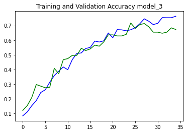

```python
# plot training accuracies
plt.plot(history_3.history['acc'],'b') #train acc
plt.plot(history_3.history['val_acc'],'g') #val acc
plt.title('Training and Validation Accuracy model_3')
plt.show()
```

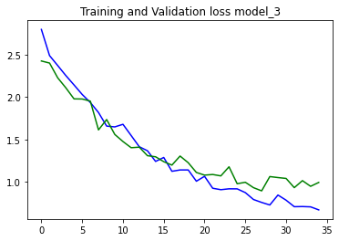

```python
# plot training and validation loss
plt.plot(history_3.history['loss'],'b') #train loss
plt.plot(history_3.history['val_loss'],'g') #val loss
plt.title('Training and Validation loss model_3')
plt.show()
```

```python
np.random.seed(1000)

model = Sequential()

# 1st Convolutional Layer
model.add(Conv2D(filters=96, input_shape=(224,224,3), kernel_size=(11,11),
 strides=(4,4), padding='valid',activation="relu"))
# Pooling
model.add(MaxPooling2D(pool_size=(2,2), strides=(2,2), padding='valid'))
# Batch Normalisation before passing it to the next layer
#model.add(BatchNormalization())

# 2nd Convolutional Layer
model.add(Conv2D(filters=256, kernel_size=(11,11), strides=(1,1), padding='valid',activation="relu"))
# Pooling
model.add(MaxPooling2D(pool_size=(2,2), strides=(2,2), padding='valid'))
# Batch Normalisation
#model.add(BatchNormalization())

# 3rd Convolutional Layer
model.add(Conv2D(filters=384, kernel_size=(3,3), strides=(1,1), padding='valid',activation='relu'))
# Batch Normalisation
#model.add(BatchNormalization())

# 4th Convolutional Layer
model.add(Conv2D(filters=384, kernel_size=(3,3), strides=(1,1), padding='valid',activation='relu'))
# Batch Normalisation
#model.add(BatchNormalization())

# 5th Convolutional Layer
model.add(Conv2D(filters=256, kernel_size=(3,3), strides=(1,1), padding='valid',activation="relu"))
# Pooling
model.add(MaxPooling2D(pool_size=(2,2), strides=(2,2), padding='valid'))
# Batch Normalisation
#model.add(BatchNormalization())

# Passing it to a dense layer
model.add(Flatten())
# 1st Dense Layer
model.add(Dense(4096, input_shape=(224*224*3,),activation="relu"))
# Add Dropout to prevent overfitting
model.add(Dropout(0.4))
# Batch Normalisation
#model.add(BatchNormalization())

# 2nd Dense Layer
model.add(Dense(4096,activation="relu"))
# Add Dropout
model.add(Dropout(0.4))
# Batch Normalisation
#model.add(BatchNormalization())

# 3rd Dense Layer
model.add(Dense(1000,activation="relu"))
# Add Dropout
model.add(Dropout(0.4))
# Batch Normalisation
#model.add(BatchNormalization())

# Output Layer
model.add(Dense(17,activation="softmax"))
model.summary()
```

```
Model: "sequential_7"
_________________________________________________________________
Layer (type)                 Output Shape              Param #
=================================================================
conv2d_27 (Conv2D)           (None, 54, 54, 96)        34944
_________________________________________________________________
max_pooling2d_25 (MaxPooling (None, 27, 27, 96)        0
_________________________________________________________________
conv2d_28 (Conv2D)           (None, 17, 17, 256)       2973952
_________________________________________________________________
max_pooling2d_26 (MaxPooling (None, 8, 8, 256)         0
_________________________________________________________________
conv2d_29 (Conv2D)           (None, 6, 6, 384)         885120
_________________________________________________________________
conv2d_30 (Conv2D)           (None, 4, 4, 384)         1327488
_________________________________________________________________
conv2d_31 (Conv2D)           (None, 2, 2, 256)         884992
_________________________________________________________________
max_pooling2d_27 (MaxPooling (None, 1, 1, 256)         0
_________________________________________________________________
flatten_7 (Flatten)          (None, 256)               0
_________________________________________________________________
dense_16 (Dense)             (None, 4096)              1052672
_________________________________________________________________
dropout_13 (Dropout)         (None, 4096)              0
_________________________________________________________________
dense_17 (Dense)             (None, 4096)              16781312
_________________________________________________________________
dropout_14 (Dropout)         (None, 4096)              0
_________________________________________________________________
dense_18 (Dense)             (None, 1000)              4097000
_________________________________________________________________
dropout_15 (Dropout)         (None, 1000)              0
_________________________________________________________________
dense_19 (Dense)             (None, 17)                17017
=================================================================
Total params: 28,054,497
Trainable params: 28,054,497
Non-trainable params: 0
_________________________________________________________________
```

```python
# Compile
model.compile(loss='categorical_crossentropy', optimizer='rmsprop', metrics=['accuracy'])
```

```python
#Train
%%time
model_4 = model
history_4 = model_4.fit_generator(datagen.flow(x_train, y_train, batch_size=100), epochs=100,validation_data=(x_test, y_test), verbose=2)
```

```
11/11 - 20s - loss: 4.0850 - acc: 0.1296 - val_loss: 78.3584 - val_acc: 0.0588
11/11 - 10s - loss: 2.7524 - acc: 0.2279 - val_loss: 37.5461 - val_acc: 0.0662
11/11 - 12s - loss: 2.5068 - acc: 0.2592 - val_loss: 57.7888 - val_acc: 0.0625
11/11 - 12s - loss: 2.5971 - acc: 0.2381 - val_loss: 22.9714 - val_acc: 0.1176
11/11 - 12s - loss: 2.4777 - acc: 0.2445 - val_loss: 28.8313 - val_acc: 0.1618
11/11 - 12s - loss: 2.4017 - acc: 0.2693 - val_loss: 70.0075 - val_acc: 0.1471
11/11 - 12s - loss: 2.2566 - acc: 0.2794 - val_loss: 16.8178 - val_acc: 0.2059
11/11 - 12s - loss: 2.2668 - acc: 0.2886 - val_loss: 66.9676 - val_acc: 0.1250
11/11 - 12s - loss: 2.2045 - acc: 0.3051 - val_loss: 25.1964 - val_acc: 0.1875
11/11 - 12s - loss: 2.0571 - acc: 0.3474 - val_loss: 16.7144 - val_acc: 0.2647
11/11 - 12s - loss: 2.0846 - acc: 0.3208 - val_loss: 135.0444 - val_acc: 0.1691
11/11 - 12s - loss: 1.9422 - acc: 0.3658 - val_loss: 44.9636 - val_acc: 0.1213
11/11 - 12s - loss: 1.7133 - acc: 0.4329 - val_loss: 27.2821 - val_acc: 0.1728
11/11 - 12s - loss: 1.7526 - acc: 0.4118 - val_loss: 31.5237 - val_acc: 0.1875
11/11 - 12s - loss: 1.7119 - acc: 0.4191 - val_loss: 12.6515 - val_acc: 0.3162
11/11 - 12s - loss: 1.7788 - acc: 0.4053 - val_loss: 8.8653 - val_acc: 0.2647
11/11 - 12s - loss: 1.7515 - acc: 0.4421 - val_loss: 5.0689 - val_acc: 0.2868
11/11 - 12s - loss: 1.6572 - acc: 0.4412 - val_loss: 22.2097 - val_acc: 0.2206
11/11 - 12s - loss: 1.5688 - acc: 0.4660 - val_loss: 11.4377 - val_acc: 0.2500
11/11 - 12s - loss: 1.5623 - acc: 0.4605 - val_loss: 16.4445 - val_acc: 0.2059
11/11 - 12s - loss: 1.5541 - acc: 0.4743 - val_loss: 13.0967 - val_acc: 0.3676
11/11 - 12s - loss: 1.4910 - acc: 0.4844 - val_loss: 4.8474 - val_acc: 0.3125
11/11 - 12s - loss: 1.5683 - acc: 0.4660 - val_loss: 5.4532 - val_acc: 0.2868
11/11 - 12s - loss: 1.3803 - acc: 0.4991 - val_loss: 9.1475 - val_acc: 0.2537
11/11 - 12s - loss: 1.4517 - acc: 0.4936 - val_loss: 10.4941 - val_acc: 0.2610
11/11 - 12s - loss: 1.4924 - acc: 0.5129 - val_loss: 3.4150 - val_acc: 0.4265
11/11 - 12s - loss: 1.4172 - acc: 0.5202 - val_loss: 2.9162 - val_acc: 0.4007
11/11 - 12s - loss: 1.3838 - acc: 0.5184 - val_loss: 3.2162 - val_acc: 0.3603
11/11 - 12s - loss: 1.3933 - acc: 0.5294 - val_loss: 4.5484 - val_acc: 0.3015
11/11 - 12s - loss: 1.3125 - acc: 0.5441 - val_loss: 7.7755 - val_acc: 0.2721
11/11 - 12s - loss: 1.3627 - acc: 0.5239 - val_loss: 4.9419 - val_acc: 0.3199
11/11 - 12s - loss: 1.3525 - acc: 0.5358 - val_loss: 3.7302 - val_acc: 0.3382
11/11 - 12s - loss: 1.2280 - acc: 0.5726 - val_loss: 3.2518 - val_acc: 0.3787
11/11 - 12s - loss: 1.2616 - acc: 0.5763 - val_loss: 3.7326 - val_acc: 0.4191
11/11 - 12s - loss: 1.2149 - acc: 0.5873 - val_loss: 2.3389 - val_acc: 0.4632
11/11 - 12s - loss: 1.2135 - acc: 0.5901 - val_loss: 2.1780 - val_acc: 0.4853
11/11 - 12s - loss: 1.2339 - acc: 0.5579 - val_loss: 2.2121 - val_acc: 0.4743
11/11 - 12s - loss: 1.1605 - acc: 0.6039 - val_loss: 3.5950 - val_acc: 0.4669
11/11 - 12s - loss: 1.2004 - acc: 0.5800 - val_loss: 3.0526 - val_acc: 0.4706
11/11 - 12s - loss: 1.1926 - acc: 0.5983 - val_loss: 3.6338 - val_acc: 0.3824
```

[output cut: 47 more lines]

```
11/11 - 12s - loss: 0.7091 - acc: 0.7730 - val_loss: 2.1095 - val_acc: 0.5515
11/11 - 12s - loss: 0.6365 - acc: 0.7941 - val_loss: 1.4845 - val_acc: 0.6029
11/11 - 12s - loss: 0.6364 - acc: 0.7849 - val_loss: 1.8920 - val_acc: 0.5956
11/11 - 12s - loss: 0.6026 - acc: 0.7987 - val_loss: 1.8300 - val_acc: 0.5882
11/11 - 12s - loss: 0.6394 - acc: 0.7812 - val_loss: 1.2651 - val_acc: 0.6471
11/11 - 12s - loss: 0.6489 - acc: 0.7711 - val_loss: 1.4017 - val_acc: 0.6397
11/11 - 12s - loss: 0.6281 - acc: 0.7904 - val_loss: 2.8745 - val_acc: 0.5000
11/11 - 12s - loss: 0.5730 - acc: 0.7904 - val_loss: 1.2946 - val_acc: 0.6471
11/11 - 12s - loss: 0.6008 - acc: 0.7923 - val_loss: 1.6379 - val_acc: 0.6397
11/11 - 12s - loss: 0.6324 - acc: 0.7794 - val_loss: 2.3166 - val_acc: 0.4963
11/11 - 12s - loss: 0.5818 - acc: 0.8024 - val_loss: 2.1925 - val_acc: 0.5882
11/11 - 12s - loss: 0.5905 - acc: 0.8015 - val_loss: 2.7998 - val_acc: 0.5184
11/11 - 12s - loss: 0.5922 - acc: 0.7969 - val_loss: 2.0780 - val_acc: 0.5441
CPU times: user 21min 40s, sys: 1min 14s, total: 22min 54s
Wall time: 19min 50s
```

```python
# Final evaluation of the model
scores_4 = model_4.evaluate(x_test, y_test, verbose=0)
print("Baseline Error: %.2f%%" % (100-scores_4[1]*100))
```

```
Baseline Error: 45.59%
```

```python
print('training acc.:',history_4.history['acc'][-1],'\n','test acc.:', (history_4.history['val_acc'])[-1])
```

```
training acc.: 0.796875
 test acc.: 0.5441176
```

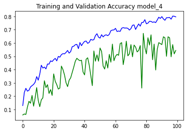

```python
# plot training accuracies
plt.plot(history_4.history['acc'],'b') #train acc
plt.plot(history_4.history['val_acc'],'g') #val acc
plt.title('Training and Validation Accuracy model_4')
plt.show()
```

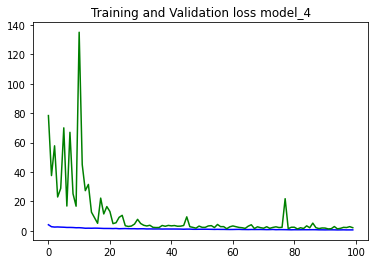

```python
# plot training and validation loss
plt.plot(history_4.history['loss'],'b') #train loss
plt.plot(history_4.history['val_loss'],'g') #val loss
plt.title('Training and Validation loss model_4')
plt.show()
```

The accuracy of the model on the test data is just 54% , from the graphs above it is evident we have overtrained the model, intially adam was used as an optimizer now using rms prop, the RMS prop optimizer has a poor performance as compared to the adam used previously

## Transfer Learning

### VGG Net

using VGG Net intitally trained on Imagenet weights

```python
# use vgg16 pre-trained model with trainable densely connected output layer

from keras.applications import VGG16
#Load the VGG model
vgg_conv = VGG16(weights='imagenet', include_top=False, input_shape=(224, 224, 3))

# Freeze all the layers except for the last layer:
for layer in vgg_conv.layers:
    layer.trainable = False

from keras import models
from keras import layers
from keras import optimizers

# Create the model
model = models.Sequential()

# Add the vgg convolutional base model
model.add(vgg_conv)

# Add new layers
#model.add(layers.Flatten())
#model.add(Dense(4096, input_shape=(224*224*3,),activation="relu"))
#model.add(Dropout(0.4))
#model.add(BatchNormalization())
#model.add(Dense(4096,activation="relu"))
#model.add(Dropout(0.4))
#model.add(BatchNormalization())
#model.add(Dense(1000,activation="relu"))
#model.add(Dropout(0.4))
#model.add(BatchNormalization())
#model.add(Dense(17,activation="softmax"))
#model.summary()
model.add(layers.Flatten())
model.add(layers.Dense(1024, activation='relu'))
model.add(layers.Dropout(0.5))
model.add(layers.Dense(17, activation='softmax'))
model.summary()
```

```
Downloading data from https://storage.googleapis.com/tensorflow/keras-applications/vgg16/vgg16_weights_tf_dim_ordering_tf_kernels_notop.h5
Model: "sequential"
_________________________________________________________________
Layer (type)                 Output Shape              Param #
=================================================================
vgg16 (Functional)           (None, 7, 7, 512)         14714688
_________________________________________________________________
flatten (Flatten)            (None, 25088)             0
_________________________________________________________________
dense (Dense)                (None, 1024)              25691136
_________________________________________________________________
dropout (Dropout)            (None, 1024)              0
_________________________________________________________________
dense_1 (Dense)              (None, 17)                17425
=================================================================
Total params: 40,423,249
Trainable params: 25,708,561
Non-trainable params: 14,714,688
_________________________________________________________________
```

```python
model.compile(loss='categorical_crossentropy',
              optimizer=optimizers.RMSprop(lr=1e-4),
              metrics=['acc', 'top_k_categorical_accuracy'])
```

```python
# training the model
%%time
history = model.fit_generator(datagen.flow(x_train, y_train, batch_size=50), epochs=50, validation_data=(x_test, y_test), verbose=2)
```

```
22/22 - 48s - loss: 5.9923 - acc: 0.2022 - top_k_categorical_accuracy: 0.5368 - val_loss: 1.8663 - val_acc: 0.4779 - val_top_k_categorical_accuracy: 0.7463
22/22 - 12s - loss: 1.8356 - acc: 0.4154 - top_k_categorical_accuracy: 0.7950 - val_loss: 1.3471 - val_acc: 0.5993 - val_top_k_categorical_accuracy: 0.9265
22/22 - 16s - loss: 1.6401 - acc: 0.4733 - top_k_categorical_accuracy: 0.8401 - val_loss: 1.1555 - val_acc: 0.6581 - val_top_k_categorical_accuracy: 0.9301
22/22 - 16s - loss: 1.3859 - acc: 0.5625 - top_k_categorical_accuracy: 0.8943 - val_loss: 0.9662 - val_acc: 0.7132 - val_top_k_categorical_accuracy: 0.9412
22/22 - 16s - loss: 1.2383 - acc: 0.6140 - top_k_categorical_accuracy: 0.9099 - val_loss: 0.8858 - val_acc: 0.7353 - val_top_k_categorical_accuracy: 0.9412
22/22 - 16s - loss: 1.1498 - acc: 0.6379 - top_k_categorical_accuracy: 0.9283 - val_loss: 0.8311 - val_acc: 0.7574 - val_top_k_categorical_accuracy: 0.9632
22/22 - 16s - loss: 1.0617 - acc: 0.6654 - top_k_categorical_accuracy: 0.9393 - val_loss: 0.8205 - val_acc: 0.7537 - val_top_k_categorical_accuracy: 0.9485
22/22 - 16s - loss: 1.0675 - acc: 0.6498 - top_k_categorical_accuracy: 0.9347 - val_loss: 0.7542 - val_acc: 0.7978 - val_top_k_categorical_accuracy: 0.9632
22/22 - 16s - loss: 0.9504 - acc: 0.7068 - top_k_categorical_accuracy: 0.9476 - val_loss: 0.7365 - val_acc: 0.7904 - val_top_k_categorical_accuracy: 0.9449
22/22 - 16s - loss: 0.9677 - acc: 0.6875 - top_k_categorical_accuracy: 0.9430 - val_loss: 0.6229 - val_acc: 0.8125 - val_top_k_categorical_accuracy: 0.9779
22/22 - 16s - loss: 0.9056 - acc: 0.7178 - top_k_categorical_accuracy: 0.9458 - val_loss: 0.6263 - val_acc: 0.8162 - val_top_k_categorical_accuracy: 0.9706
22/22 - 16s - loss: 0.9100 - acc: 0.6994 - top_k_categorical_accuracy: 0.9577 - val_loss: 0.6063 - val_acc: 0.8235 - val_top_k_categorical_accuracy: 0.9743
22/22 - 16s - loss: 0.8498 - acc: 0.7390 - top_k_categorical_accuracy: 0.9568 - val_loss: 0.5864 - val_acc: 0.8309 - val_top_k_categorical_accuracy: 0.9779
22/22 - 16s - loss: 0.8189 - acc: 0.7426 - top_k_categorical_accuracy: 0.9577 - val_loss: 0.5789 - val_acc: 0.8382 - val_top_k_categorical_accuracy: 0.9596
22/22 - 16s - loss: 0.7969 - acc: 0.7463 - top_k_categorical_accuracy: 0.9651 - val_loss: 0.5458 - val_acc: 0.8309 - val_top_k_categorical_accuracy: 0.9596
22/22 - 16s - loss: 0.7985 - acc: 0.7344 - top_k_categorical_accuracy: 0.9688 - val_loss: 0.5346 - val_acc: 0.8382 - val_top_k_categorical_accuracy: 0.9743
22/22 - 16s - loss: 0.7256 - acc: 0.7665 - top_k_categorical_accuracy: 0.9651 - val_loss: 0.5568 - val_acc: 0.8309 - val_top_k_categorical_accuracy: 0.9779
22/22 - 16s - loss: 0.7244 - acc: 0.7711 - top_k_categorical_accuracy: 0.9706 - val_loss: 0.5334 - val_acc: 0.8456 - val_top_k_categorical_accuracy: 0.9779
22/22 - 16s - loss: 0.7678 - acc: 0.7592 - top_k_categorical_accuracy: 0.9678 - val_loss: 0.5745 - val_acc: 0.8235 - val_top_k_categorical_accuracy: 0.9743
22/22 - 16s - loss: 0.7218 - acc: 0.7794 - top_k_categorical_accuracy: 0.9678 - val_loss: 0.4847 - val_acc: 0.8529 - val_top_k_categorical_accuracy: 0.9816
22/22 - 19s - loss: 0.6976 - acc: 0.7849 - top_k_categorical_accuracy: 0.9752 - val_loss: 0.5267 - val_acc: 0.8235 - val_top_k_categorical_accuracy: 0.9816
22/22 - 15s - loss: 0.6703 - acc: 0.7748 - top_k_categorical_accuracy: 0.9697 - val_loss: 0.4876 - val_acc: 0.8382 - val_top_k_categorical_accuracy: 0.9779
22/22 - 16s - loss: 0.6297 - acc: 0.7822 - top_k_categorical_accuracy: 0.9761 - val_loss: 0.5081 - val_acc: 0.8603 - val_top_k_categorical_accuracy: 0.9779
22/22 - 16s - loss: 0.6230 - acc: 0.7914 - top_k_categorical_accuracy: 0.9733 - val_loss: 0.5263 - val_acc: 0.8493 - val_top_k_categorical_accuracy: 0.9779
22/22 - 16s - loss: 0.6750 - acc: 0.7794 - top_k_categorical_accuracy: 0.9669 - val_loss: 0.4765 - val_acc: 0.8824 - val_top_k_categorical_accuracy: 0.9743
22/22 - 16s - loss: 0.6241 - acc: 0.8015 - top_k_categorical_accuracy: 0.9761 - val_loss: 0.4621 - val_acc: 0.8566 - val_top_k_categorical_accuracy: 0.9779
22/22 - 16s - loss: 0.6610 - acc: 0.7923 - top_k_categorical_accuracy: 0.9770 - val_loss: 0.5159 - val_acc: 0.8566 - val_top_k_categorical_accuracy: 0.9706
22/22 - 16s - loss: 0.6128 - acc: 0.8061 - top_k_categorical_accuracy: 0.9779 - val_loss: 0.4882 - val_acc: 0.8529 - val_top_k_categorical_accuracy: 0.9779
22/22 - 16s - loss: 0.6600 - acc: 0.7693 - top_k_categorical_accuracy: 0.9770 - val_loss: 0.4619 - val_acc: 0.8493 - val_top_k_categorical_accuracy: 0.9779
22/22 - 16s - loss: 0.5921 - acc: 0.7914 - top_k_categorical_accuracy: 0.9816 - val_loss: 0.5064 - val_acc: 0.8493 - val_top_k_categorical_accuracy: 0.9816
22/22 - 16s - loss: 0.5863 - acc: 0.8107 - top_k_categorical_accuracy: 0.9825 - val_loss: 0.5099 - val_acc: 0.8529 - val_top_k_categorical_accuracy: 0.9816
22/22 - 16s - loss: 0.6158 - acc: 0.7969 - top_k_categorical_accuracy: 0.9770 - val_loss: 0.4685 - val_acc: 0.8566 - val_top_k_categorical_accuracy: 0.9853
22/22 - 16s - loss: 0.5774 - acc: 0.8097 - top_k_categorical_accuracy: 0.9789 - val_loss: 0.4738 - val_acc: 0.8493 - val_top_k_categorical_accuracy: 0.9779
22/22 - 16s - loss: 0.6151 - acc: 0.8042 - top_k_categorical_accuracy: 0.9724 - val_loss: 0.4877 - val_acc: 0.8529 - val_top_k_categorical_accuracy: 0.9779
```

[output cut: 18 more lines]

```python
# Final evaluation of the model
scores_vgg = model.evaluate(x_test, y_test, verbose=0)
print("Baseline Error: %.2f%%" % (100-scores_vgg[1]*100))
```

```
Baseline Error: 12.50%
```

```python
print('training acc.:',history.history['acc'][-1],'\n','test acc.:', (history.history['val_acc'])[-1])
```

```
training acc.: 0.82169116
 test acc.: 0.875
```

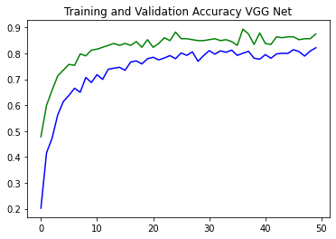

```python
# plot training accuracies
plt.plot(history.history['acc'],'b') #train acc
plt.plot(history.history['val_acc'],'g') #val acc
plt.title('Training and Validation Accuracy VGG Net')
plt.show()
```

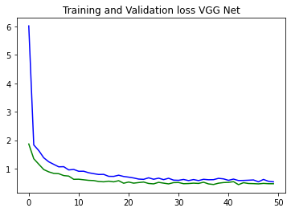

```python
# plot training and validation loss
plt.plot(history.history['loss'],'b') #train loss
plt.plot(history.history['val_loss'],'g') #val loss
plt.title('Training and Validation loss VGG Net')
plt.show()
```

```python
%%time
history_2 = model.fit_generator(datagen.flow(x_train, y_train, batch_size=50), epochs=50, validation_data=(x_test, y_test), verbose=2)
```

```
22/22 - 18s - loss: 0.4532 - acc: 0.8392 - top_k_categorical_accuracy: 0.9881 - val_loss: 0.4408 - val_acc: 0.8860 - val_top_k_categorical_accuracy: 0.9816
22/22 - 16s - loss: 0.3997 - acc: 0.8603 - top_k_categorical_accuracy: 0.9917 - val_loss: 0.4835 - val_acc: 0.8787 - val_top_k_categorical_accuracy: 0.9853
22/22 - 16s - loss: 0.3625 - acc: 0.8805 - top_k_categorical_accuracy: 0.9945 - val_loss: 0.4340 - val_acc: 0.8824 - val_top_k_categorical_accuracy: 0.9816
22/22 - 16s - loss: 0.3650 - acc: 0.8750 - top_k_categorical_accuracy: 0.9917 - val_loss: 0.4370 - val_acc: 0.8897 - val_top_k_categorical_accuracy: 0.9853
22/22 - 16s - loss: 0.3806 - acc: 0.8750 - top_k_categorical_accuracy: 0.9945 - val_loss: 0.4490 - val_acc: 0.8750 - val_top_k_categorical_accuracy: 0.9853
22/22 - 16s - loss: 0.3609 - acc: 0.8722 - top_k_categorical_accuracy: 0.9945 - val_loss: 0.4247 - val_acc: 0.8860 - val_top_k_categorical_accuracy: 0.9853
22/22 - 16s - loss: 0.3563 - acc: 0.8741 - top_k_categorical_accuracy: 0.9954 - val_loss: 0.4407 - val_acc: 0.8750 - val_top_k_categorical_accuracy: 0.9853
22/22 - 16s - loss: 0.3243 - acc: 0.8943 - top_k_categorical_accuracy: 0.9954 - val_loss: 0.4529 - val_acc: 0.8860 - val_top_k_categorical_accuracy: 0.9816
22/22 - 16s - loss: 0.3580 - acc: 0.8778 - top_k_categorical_accuracy: 0.9917 - val_loss: 0.4421 - val_acc: 0.8824 - val_top_k_categorical_accuracy: 0.9816
22/22 - 16s - loss: 0.3975 - acc: 0.8594 - top_k_categorical_accuracy: 0.9871 - val_loss: 0.4718 - val_acc: 0.8750 - val_top_k_categorical_accuracy: 0.9816
22/22 - 16s - loss: 0.3344 - acc: 0.8851 - top_k_categorical_accuracy: 0.9963 - val_loss: 0.4493 - val_acc: 0.9044 - val_top_k_categorical_accuracy: 0.9853
22/22 - 16s - loss: 0.3722 - acc: 0.8851 - top_k_categorical_accuracy: 0.9963 - val_loss: 0.4290 - val_acc: 0.8897 - val_top_k_categorical_accuracy: 0.9853
22/22 - 16s - loss: 0.3124 - acc: 0.8915 - top_k_categorical_accuracy: 0.9954 - val_loss: 0.4508 - val_acc: 0.8897 - val_top_k_categorical_accuracy: 0.9853
22/22 - 16s - loss: 0.3324 - acc: 0.8851 - top_k_categorical_accuracy: 0.9972 - val_loss: 0.4538 - val_acc: 0.8824 - val_top_k_categorical_accuracy: 0.9853
22/22 - 16s - loss: 0.3140 - acc: 0.9017 - top_k_categorical_accuracy: 0.9936 - val_loss: 0.4574 - val_acc: 0.8824 - val_top_k_categorical_accuracy: 0.9853
22/22 - 16s - loss: 0.3114 - acc: 0.8805 - top_k_categorical_accuracy: 0.9963 - val_loss: 0.4300 - val_acc: 0.8860 - val_top_k_categorical_accuracy: 0.9853
22/22 - 16s - loss: 0.2958 - acc: 0.9044 - top_k_categorical_accuracy: 0.9926 - val_loss: 0.4418 - val_acc: 0.8860 - val_top_k_categorical_accuracy: 0.9816
22/22 - 16s - loss: 0.2918 - acc: 0.8989 - top_k_categorical_accuracy: 0.9963 - val_loss: 0.4428 - val_acc: 0.8934 - val_top_k_categorical_accuracy: 0.9853
22/22 - 16s - loss: 0.3309 - acc: 0.8897 - top_k_categorical_accuracy: 0.9936 - val_loss: 0.4417 - val_acc: 0.8787 - val_top_k_categorical_accuracy: 0.9853
22/22 - 16s - loss: 0.3198 - acc: 0.8897 - top_k_categorical_accuracy: 0.9945 - val_loss: 0.4936 - val_acc: 0.8640 - val_top_k_categorical_accuracy: 0.9853
22/22 - 16s - loss: 0.3195 - acc: 0.8860 - top_k_categorical_accuracy: 0.9963 - val_loss: 0.4358 - val_acc: 0.8897 - val_top_k_categorical_accuracy: 0.9853
22/22 - 16s - loss: 0.2862 - acc: 0.9072 - top_k_categorical_accuracy: 0.9972 - val_loss: 0.4673 - val_acc: 0.8897 - val_top_k_categorical_accuracy: 0.9853
22/22 - 16s - loss: 0.3152 - acc: 0.8915 - top_k_categorical_accuracy: 0.9926 - val_loss: 0.4346 - val_acc: 0.8824 - val_top_k_categorical_accuracy: 0.9853
22/22 - 16s - loss: 0.3299 - acc: 0.8787 - top_k_categorical_accuracy: 0.9972 - val_loss: 0.4101 - val_acc: 0.9007 - val_top_k_categorical_accuracy: 0.9853
22/22 - 16s - loss: 0.3479 - acc: 0.8943 - top_k_categorical_accuracy: 0.9936 - val_loss: 0.4351 - val_acc: 0.8934 - val_top_k_categorical_accuracy: 0.9890
22/22 - 16s - loss: 0.3115 - acc: 0.8824 - top_k_categorical_accuracy: 0.9963 - val_loss: 0.4697 - val_acc: 0.8824 - val_top_k_categorical_accuracy: 0.9816
22/22 - 16s - loss: 0.3255 - acc: 0.8860 - top_k_categorical_accuracy: 0.9945 - val_loss: 0.4285 - val_acc: 0.8934 - val_top_k_categorical_accuracy: 0.9853
22/22 - 16s - loss: 0.3098 - acc: 0.8980 - top_k_categorical_accuracy: 0.9954 - val_loss: 0.4450 - val_acc: 0.8934 - val_top_k_categorical_accuracy: 0.9853
22/22 - 16s - loss: 0.3330 - acc: 0.8934 - top_k_categorical_accuracy: 0.9926 - val_loss: 0.4303 - val_acc: 0.8934 - val_top_k_categorical_accuracy: 0.9853
22/22 - 16s - loss: 0.2976 - acc: 0.9062 - top_k_categorical_accuracy: 0.9963 - val_loss: 0.4852 - val_acc: 0.8676 - val_top_k_categorical_accuracy: 0.9816
22/22 - 16s - loss: 0.2710 - acc: 0.9081 - top_k_categorical_accuracy: 0.9963 - val_loss: 0.4606 - val_acc: 0.8824 - val_top_k_categorical_accuracy: 0.9816
22/22 - 16s - loss: 0.2724 - acc: 0.9136 - top_k_categorical_accuracy: 0.9954 - val_loss: 0.4728 - val_acc: 0.8897 - val_top_k_categorical_accuracy: 0.9816
22/22 - 16s - loss: 0.3041 - acc: 0.8989 - top_k_categorical_accuracy: 0.9936 - val_loss: 0.4395 - val_acc: 0.9007 - val_top_k_categorical_accuracy: 0.9779
22/22 - 16s - loss: 0.3215 - acc: 0.8943 - top_k_categorical_accuracy: 0.9936 - val_loss: 0.4529 - val_acc: 0.8897 - val_top_k_categorical_accuracy: 0.9816
```

[output cut: 18 more lines]

```python
print('training acc.:',history_2.history['acc'][-1],'\n','test acc.:', (history.history['val_acc'])[-1])
```

```
training acc.: 0.9181985
 test acc.: 0.875
```

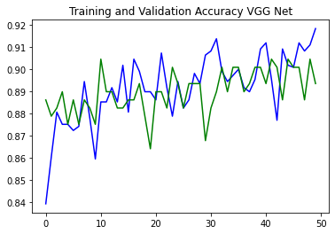

```python
# plot training accuracies
plt.plot(history_2.history['acc'],'b') #train acc
plt.plot(history_2.history['val_acc'],'g') #val acc
plt.title('Training and Validation Accuracy VGG Net')
plt.show()
```

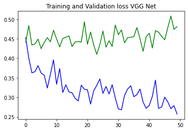

```python
# plot training and validation loss
plt.plot(history_2.history['loss'],'b') #train loss
plt.plot(history_2.history['val_loss'],'g') #val loss
plt.title('Training and Validation loss VGG Net')
plt.show()
```

```python
from keras.callbacks import EarlyStopping
earlystop = EarlyStopping(monitor = 'val_acc',
                          min_delta = 0,
                          patience = 30,
                          verbose = 1,
                          restore_best_weights = True)
```

```python
from keras.callbacks import ModelCheckpoint
checkpoint_path = "training_1/my_best_model.epoch{epoch:02d}-loss{val_loss:.2f}.hdf5"
checkpoint_dir = os.path.dirname(checkpoint_path)

checkpoint = ModelCheckpoint(checkpoint_path,
                             monitor='val_acc',
                             mode='max',
                             save_best_only=True,
                             verbose=1)
```

```python
model.compile(loss='categorical_crossentropy',
              optimizer=optimizers.RMSprop(learning_rate=1e-4),
              metrics=['acc', 'top_k_categorical_accuracy'])
```

```python
#Step decay schedule drops the learning rate by a factor every few epochs.
#import math
#def step_decay(epoch):
#   initial_lrate = 0.00001
#   drop = 0.0005
#   epochs_drop = 10.0
#   lrate = initial_lrate * math.pow(drop,
#           math.floor((1+epoch)/epochs_drop))
#   return lrate
```

```python
# Exponential decay
#def exp_decay(epoch):
##   initial_lrate = 0.00001
#   k = 0.1
#   lrate = initial_lrate * np.exp(-k*t)
#   return lrate
```

```python
callback_list = [earlystop,checkpoint]
```

```python
%%time
history_3 = model.fit_generator(datagen.flow(x_train, y_train, batch_size=50), epochs=100, validation_data=(x_test, y_test),callbacks=[checkpoint], verbose=2)
```

```
Epoch 00001: val_acc improved from -inf to 0.87132, saving model to training_1/my_best_model.epoch01-loss0.47.hdf5
22/22 - 14s - loss: 0.1052 - acc: 0.9623 - top_k_categorical_accuracy: 1.0000 - val_loss: 0.4736 - val_acc: 0.8713 - val_top_k_categorical_accuracy: 0.9963

Epoch 00002: val_acc improved from 0.87132 to 0.88603, saving model to training_1/my_best_model.epoch02-loss0.39.hdf5
22/22 - 13s - loss: 0.1234 - acc: 0.9586 - top_k_categorical_accuracy: 0.9991 - val_loss: 0.3947 - val_acc: 0.8860 - val_top_k_categorical_accuracy: 0.9963

Epoch 00003: val_acc did not improve from 0.88603
22/22 - 13s - loss: 0.1301 - acc: 0.9540 - top_k_categorical_accuracy: 1.0000 - val_loss: 0.4666 - val_acc: 0.8603 - val_top_k_categorical_accuracy: 1.0000

Epoch 00004: val_acc improved from 0.88603 to 0.89338, saving model to training_1/my_best_model.epoch04-loss0.35.hdf5
22/22 - 13s - loss: 0.1174 - acc: 0.9651 - top_k_categorical_accuracy: 1.0000 - val_loss: 0.3464 - val_acc: 0.8934 - val_top_k_categorical_accuracy: 0.9963

Epoch 00005: val_acc did not improve from 0.89338
22/22 - 13s - loss: 0.1257 - acc: 0.9605 - top_k_categorical_accuracy: 1.0000 - val_loss: 0.4031 - val_acc: 0.8897 - val_top_k_categorical_accuracy: 0.9926

Epoch 00006: val_acc did not improve from 0.89338
22/22 - 13s - loss: 0.1103 - acc: 0.9605 - top_k_categorical_accuracy: 1.0000 - val_loss: 0.3697 - val_acc: 0.8897 - val_top_k_categorical_accuracy: 0.9963

Epoch 00007: val_acc did not improve from 0.89338
22/22 - 13s - loss: 0.1367 - acc: 0.9568 - top_k_categorical_accuracy: 1.0000 - val_loss: 0.3515 - val_acc: 0.8934 - val_top_k_categorical_accuracy: 1.0000

Epoch 00008: val_acc did not improve from 0.89338
22/22 - 13s - loss: 0.0984 - acc: 0.9706 - top_k_categorical_accuracy: 0.9982 - val_loss: 0.3946 - val_acc: 0.8824 - val_top_k_categorical_accuracy: 0.9963

Epoch 00009: val_acc did not improve from 0.89338
22/22 - 13s - loss: 0.1180 - acc: 0.9568 - top_k_categorical_accuracy: 1.0000 - val_loss: 0.3941 - val_acc: 0.8860 - val_top_k_categorical_accuracy: 1.0000

Epoch 00010: val_acc did not improve from 0.89338
22/22 - 13s - loss: 0.1279 - acc: 0.9559 - top_k_categorical_accuracy: 0.9991 - val_loss: 0.3801 - val_acc: 0.8934 - val_top_k_categorical_accuracy: 0.9963

Epoch 00011: val_acc improved from 0.89338 to 0.89706, saving model to training_1/my_best_model.epoch11-loss0.35.hdf5
22/22 - 13s - loss: 0.1383 - acc: 0.9559 - top_k_categorical_accuracy: 0.9982 - val_loss: 0.3460 - val_acc: 0.8971 - val_top_k_categorical_accuracy: 0.9963

Epoch 00012: val_acc did not improve from 0.89706
22/22 - 13s - loss: 0.1337 - acc: 0.9577 - top_k_categorical_accuracy: 0.9982 - val_loss: 0.4143 - val_acc: 0.8750 - val_top_k_categorical_accuracy: 0.9963

Epoch 00013: val_acc did not improve from 0.89706
22/22 - 13s - loss: 0.1368 - acc: 0.9513 - top_k_categorical_accuracy: 1.0000 - val_loss: 0.4789 - val_acc: 0.8713 - val_top_k_categorical_accuracy: 0.9963

Epoch 00014: val_acc did not improve from 0.89706
```

[output cut: 246 more lines]

```
22/22 - 13s - loss: 0.0971 - acc: 0.9660 - top_k_categorical_accuracy: 1.0000 - val_loss: 0.4421 - val_acc: 0.8713 - val_top_k_categorical_accuracy: 0.9926

Epoch 00097: val_acc did not improve from 0.90809
22/22 - 13s - loss: 0.1087 - acc: 0.9651 - top_k_categorical_accuracy: 0.9991 - val_loss: 0.4714 - val_acc: 0.8824 - val_top_k_categorical_accuracy: 0.9926

Epoch 00098: val_acc did not improve from 0.90809
22/22 - 13s - loss: 0.1097 - acc: 0.9660 - top_k_categorical_accuracy: 0.9991 - val_loss: 0.4708 - val_acc: 0.8787 - val_top_k_categorical_accuracy: 0.9963

Epoch 00099: val_acc did not improve from 0.90809
22/22 - 13s - loss: 0.0867 - acc: 0.9669 - top_k_categorical_accuracy: 1.0000 - val_loss: 0.5870 - val_acc: 0.8750 - val_top_k_categorical_accuracy: 0.9963

Epoch 00100: val_acc did not improve from 0.90809
22/22 - 13s - loss: 0.0849 - acc: 0.9669 - top_k_categorical_accuracy: 0.9991 - val_loss: 0.4682 - val_acc: 0.8824 - val_top_k_categorical_accuracy: 0.9963
CPU times: user 22min 59s, sys: 36.7 s, total: 23min 36s
Wall time: 21min 16s
```

```python
print('training acc.:',history_3.history['acc'][-1],'\n','test acc.:', (history_3.history['val_acc'])[-1])
```

```
training acc.: 0.9669118
 test acc.: 0.88235295
```

```python
from tensorflow.keras.models import save_model, load_model
# Load the model with best weights
model = load_model("/content/training_1/my_best_model.epoch17-loss0.34.hdf5", compile = True)
```

```python
# Final evaluation of the model
scores = model.evaluate(x_test, y_test, verbose=0)
print("Baseline Error: %.2f%%" % (100-scores[1]*100))
```

```
Baseline Error: 9.19%
```

```python
print("%s: %.2f%%" % (model.metrics_names[1], scores[1]*100))
```

```
acc: 90.81%
```

```python
# prediction using the best model above
pred_image=plt.imread("/content/Prediction - Flower.jpg")
pred_image = np.asarray(pred_image)
pred_image.shape
```

```
(224, 224, 3)
```

```python
# setting up the dimenstions of the image
pred = pred_image.reshape(-1,224,224,3)
# predicting the label
output = model.predict(pred)
for i in range(17):
  if output[0,i] == 1:
    print("The output label is", i)
```

```
The output label is 2
```

```python
# checking if the output is predicted correctly or not
# images with lables 2

indx = []
for i in range(len(labels)):
  if labels[i] == 2 :
    indx.append(i)
#labels.index(2)
print("The index of label 2 images are",indx)
```

[output not shown]

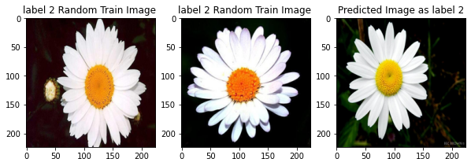

```python
plt.subplots(figsize=(10,5))
plt.subplot(131)
plt.imshow(X[197])
plt.title("label 2 Random Train Image ")
plt.subplot(132)
plt.imshow(X[169])
plt.title("label 2 Random Train Image ")
plt.subplot(133)
plt.imshow(pred_image)
plt.title("Predicted Image as label 2")
plt.show()
```

# GUI

No idea how GUI runs in COLAB, so have created GUI on local machine , below is the code for reference have attached a separate file with best model, you might need to upload the attached model to your working directory in order GUI to run, if this is just to test how a GUI looks, than the notebook is good enough

```python
# Building a GUI for Project 8 CNN '
import tkinter as tk
from tkinter import ttk # ttk is for an
import pandas as pd
import re
import pickle
import joblib
import h5py
import tensorflow as tf
import os
import sys
import matplotlib.pyplot as plt
import numpy as np
from tensorflow.keras.models import  load_model
```

```python
# window/layout

win = tk.Tk()
win.title('Image Classifier GUI-Great Learning') # window title
####################################################
name = ttk.Label(win,text="step 1: File Name")
name.grid(row = 0, column = 0 , sticky = tk.W)
name_var = tk.StringVar()
name_entrybox = ttk.Entry(win, width = 16, textvariable = name_var)
name_entrybox.grid(row=0,column=1)
def Import_Data():
    global pred_image
    image_name = name_var.get()
    image_extension = re.findall("\..*",image_name)
    if image_extension == [".jpg"]:
        pred_image= plt.imread(image_name)
        confirm = "JPG Image Found"
    elif image_extension != [".jpg"]:
            confirm = "Upload JPG Image"
    else :
        confirm = "Check Image Extension"
    confirm_entrybox=ttk.Entry(win,width=25)
    confirm_entrybox.grid(row=0,column=3)
    confirm_entrybox.insert(1,str(confirm))
Import_Data_Button = ttk.Button(win,text="Import Data",command=Import_Data)
Import_Data_Button.grid(row=0,column=2)
##########################################################
img_class = ttk.Label(win,text = "Image Classifier")
img_class.grid(row=1,column = 0,sticky=tk.W)
##########################################################

def train():
    global pred_image
    pred_image = np.asarray(pred_image)
    pred = pred_image.reshape(-1,224,224,3)
    model = load_model("best_model.hdf5", compile = True)
    output = model.predict(pred)
    for i in range(17):
        if output[0,i] == 1:
            output_label= i
    confirm = str(output_label)
    confirm_entrybox=ttk.Entry(win,width=25)
    confirm_entrybox.grid(row=2,column=3)
    confirm_entrybox.insert(1,str("Predicted Label is "+confirm))
train_Button = ttk.Button(win,text="Train classifier",command=train)
train_Button.grid(row=2,column=0)

win.mainloop()
```

# PART 5 Stratergy to maintain and support AIML Image classifier after it is in production

Ans To detect changes in data distribution we can proceed by monitoring both the output and the input of the machine learning model. One key metric to monitor the outputs is the % of predicted labels

1 – monitor your data 2 – supervise data labeling

Since in real life models performance decay with time it is necessary to keep humans in the loop throughout production. Humans are essential to:

Validate prediction with low confidence Relabel data in order to retrain models